# Aperture Statistics

Niklas Hausmann

02/07/2020

# Introduction

This file explains how we ran the statistical tests on the aperture size measurements. It is based on the `Aps` dataframe, which we created in the **Basic Shell Information.R** file. First, we need to source the ‘Apertures.csv’ file through:

```r
library(here)
library(tidyverse)
Aps <- read.csv(here("data/Apertures.csv"))
```

To get a simple list of each measurement grouped by site and bulk sample number:

```r
Aps[1:3,1:3]
```

```
##     Site Sample Aperture
## 1 KM1048    926    24.02
## 2 KM1048    926    18.13
## 3 KM1048    926    20.07
```

# General aperture statistics by areas

To look at the general statistics for each areas, we added a column to `Aps` containing the respective bay areas and summarise the dataframe using the `summarySE` function:

```r
Aps <- Aps %>%
  mutate(Area = ifelse(grepl("KM", Site), "Khur Maadi",
                   ifelse(grepl("JW", Site), "Janaba West", "Janaba East")
  ))

source("summarySE.R")

Aps_area <-summarySE(na.omit(Aps), measurevar = "Aperture", groupvars = c("Area"))
Aps_area[1:3,1:5]
```

```
##          Area    N Aperture_mean Aperture_median       sd
## 1 Janaba East 5169      19.67116           19.60 1.483827
## 2 Janaba West 6171      21.39223           21.30 1.648272
## 3  Khur Maadi 4122      22.87554           22.85 1.821071
```

## One-way anova

Doing a one-way analysis of variance (anova) will show whether there are statistically significant differences between the means of each bay area.

```r
Aps_area_aov <- aov(Aperture ~ Area, data = Aps)
summary(Aps_area_aov)
```

```
##                Df Sum Sq Mean Sq F value Pr(>F)
## Area            2  23880   11940    4415 <2e-16 ***
## Residuals   15459  41808       3
## ---
## Signif. codes:  0 '***' 0.001 '**' 0.01 '*' 0.05 '.' 0.1 ' ' 1
```

## Post-hoc tukey test

We then applied a post-hoc tukey test, to understand between which areas the statistically significant differences lie.

```r
TukeyHSD(Aps_area_aov)
```

```
##   Tukey multiple comparisons of means
##     95% family-wise confidence level
##
## Fit: aov(formula = Aperture ~ Area, data = Aps)
##
## $Area
##                             diff      lwr      upr p adj
## Janaba West-Janaba East 1.721064 1.648385 1.793743     0
## Khur Maadi-Janaba East  3.204381 3.123888 3.284873     0
## Khur Maadi-Janaba West  1.483317 1.405778 1.560856     0
```

## Graph of size distributions by area (Fig. 6a)

To illustrate these differences, our paper used [raincloud plots](https://github.com/RainCloudPlots/RainCloudPlots), as well as other design-related packages, such as `viridis` and `cowplot`.

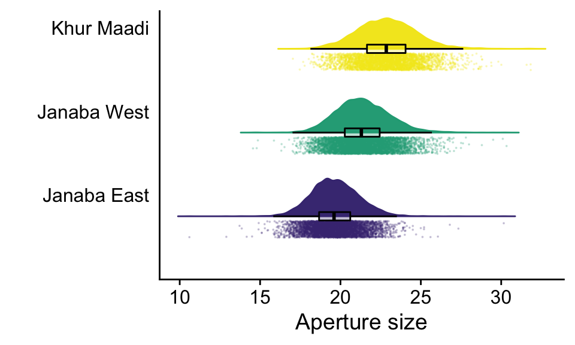

```r
library(ggplot2)
library(cowplot)
library(viridis)
source('R_rainclouds.R')

Fig6a <- Aps %>%
      ggplot(aes(
  x = Area,
  y = Aperture,
  fill = Area,
  colour = Area
)) +
  geom_flat_violin(
    position = position_nudge(x = +0.155, y = 0),
    adjust = 0.75,
    trim = FALSE,
    alpha = .99
  ) +
  geom_point(position = position_jitter(width = .1),
             size = 0.05,alpha=0.2

  ) +
  geom_boxplot(
    position = position_nudge(x = +0.155, y = 0),
    aes(x = Area, y = Aperture,colour=Area),
    outlier.shape = NA,
    alpha = 0.3,
    width = .1,
    colour = "BLACK",show.legend = FALSE
  ) +
  ylab('Aperture size') + xlab('') + coord_flip() + guides(fill = FALSE, colour = FALSE) +
  scale_color_manual(values=c(viridis_pal()(60)[10],viridis_pal()(6)[4],viridis_pal()(60)[59]))+
  scale_fill_manual(values=c(viridis_pal()(60)[10],viridis_pal()(6)[4],viridis_pal()(60)[59]))+
  theme_cowplot()+
  theme(axis.text.y.left = element_text(vjust=-2))+theme(axis.ticks.y=element_blank())

Fig6a
```

# General aperture statistics by sites

To do the same tests between sites, we have to take similar steps, only this time we are also using the `Site` column to group aperture measurements.

```r
PW_Aps <- pairwise.wilcox.test(Aps$Aperture, Aps$Site,  p.adjust.method = "bonferroni")
PW_Aps
```

```
##
##  Pairwise comparisons using Wilcoxon rank sum test
##
## data:  Aps$Aperture and Aps$Site
##
##          JE0003  JE0004  JE0078  JE0087  JE5642  JW1705  JW1727_A JW1727_B
## JE0004   0.63341 -       -       -       -       -       -        -
## JE0078   1.00000 < 2e-16 -       -       -       -       -        -
## JE0087   1.00000 < 2e-16 < 2e-16 -       -       -       -        -
## JE5642   1.00000 < 2e-16 4.5e-08 1.00000 -       -       -        -
## JW1705   0.01027 < 2e-16 < 2e-16 < 2e-16 < 2e-16 -       -        -
## JW1727_A 1.00000 < 2e-16 < 2e-16 < 2e-16 8.3e-08 < 2e-16 -        -
## JW1727_B 1.00000 < 2e-16 < 2e-16 < 2e-16 0.00032 < 2e-16 1.00000  -
## JW1807   0.01014 < 2e-16 < 2e-16 < 2e-16 < 2e-16 1.00000 < 2e-16  < 2e-16
## JW1864   1.00000 < 2e-16 < 2e-16 < 2e-16 0.00197 < 2e-16 0.00316  1.00000
## JW2298   1.00000 < 2e-16 < 2e-16 < 2e-16 3.8e-06 3.7e-10 1.00000  1.00000
## JW3120   0.38053 < 2e-16 < 2e-16 < 2e-16 1.5e-15 9.5e-05 1.4e-05  1.9e-07
## KM1048   1.00000 1.00000 1.00000 1.00000 1.00000 1.00000 1.00000  1.00000
## KM1050   0.00153 < 2e-16 < 2e-16 < 2e-16 < 2e-16 7.7e-06 < 2e-16  < 2e-16
## KM1051   0.19107 < 2e-16 < 2e-16 5.0e-16 5.3e-08 1.00000 0.00331  0.00051
## KM1052   1.00000 1.2e-15 4.1e-10 1.1e-06 0.00568 1.00000 1.00000  1.00000
## KM1053   0.00407 < 2e-16 < 2e-16 < 2e-16 < 2e-16 1.00000 3.7e-16  < 2e-16
## KM1054   0.19211 3.4e-10 2.5e-08 3.9e-07 2.1e-05 0.52703 0.00090  0.00047
## KM1056   1.00000 1.00000 1.00000 1.00000 1.00000 1.00000 1.00000  1.00000
## KM1057   0.00202 < 2e-16 < 2e-16 < 2e-16 < 2e-16 0.00011 < 2e-16  < 2e-16
## KM1304   1.00000 3.6e-16 9.2e-10 5.3e-06 0.01192 1.00000 1.00000  1.00000
## KM1307   0.04016 3.3e-15 1.2e-12 6.1e-11 4.5e-07 1.00000 0.00028  9.5e-05
## KM1313   0.00086 < 2e-16 < 2e-16 < 2e-16 < 2e-16 6.4e-06 < 2e-16  < 2e-16
## KM1317   0.00382 < 2e-16 < 2e-16 < 2e-16 6.5e-15 1.00000 1.1e-10  1.4e-11
## KM1328   0.02436 < 2e-16 < 2e-16 < 2e-16 4.1e-15 0.01718 8.1e-12  3.0e-12
## KM1330   0.00269 < 2e-16 < 2e-16 < 2e-16 3.6e-13 0.06750 2.8e-10  7.0e-11
## KM1335   0.00533 < 2e-16 < 2e-16 < 2e-16 < 2e-16 0.13757 2.4e-13  7.1e-14
## KM1336   0.00465 < 2e-16 < 2e-16 < 2e-16 1.0e-15 0.67647 1.9e-11  2.3e-12
##          JW1807  JW1864  JW2298  JW3120  KM1048  KM1050  KM1051  KM1052
## JE0004   -       -       -       -       -       -       -       -
## JE0078   -       -       -       -       -       -       -       -
## JE0087   -       -       -       -       -       -       -       -
## JE5642   -       -       -       -       -       -       -       -
## JW1705   -       -       -       -       -       -       -       -
## JW1727_A -       -       -       -       -       -       -       -
```

[output cut: 64 more lines]

```
## KM1052   -       -       -
## KM1053   -       -       -
## KM1054   -       -       -
## KM1056   -       -       -
## KM1057   -       -       -
## KM1304   -       -       -
## KM1307   -       -       -
## KM1313   -       -       -
## KM1317   -       -       -
## KM1328   -       -       -
## KM1330   1.00000 -       -
## KM1335   1.00000 1.00000 -
## KM1336   1.00000 1.00000 1.00000
##
## P value adjustment method: bonferroni
```

## Graph of size distributions by site (Fig. 6b)

Similar to the graph above, we illustrate the site differences using [raincloud plots](https://github.com/RainCloudPlots/RainCloudPlots), as well as other design-related packages, such as `viridis` and `cowplot`. This time, the sites are coloured by bay area, however they are in the order of largst shells (top) to smallest shells (bottom). The general trend, however, remains and sites usually stick to their bay area.

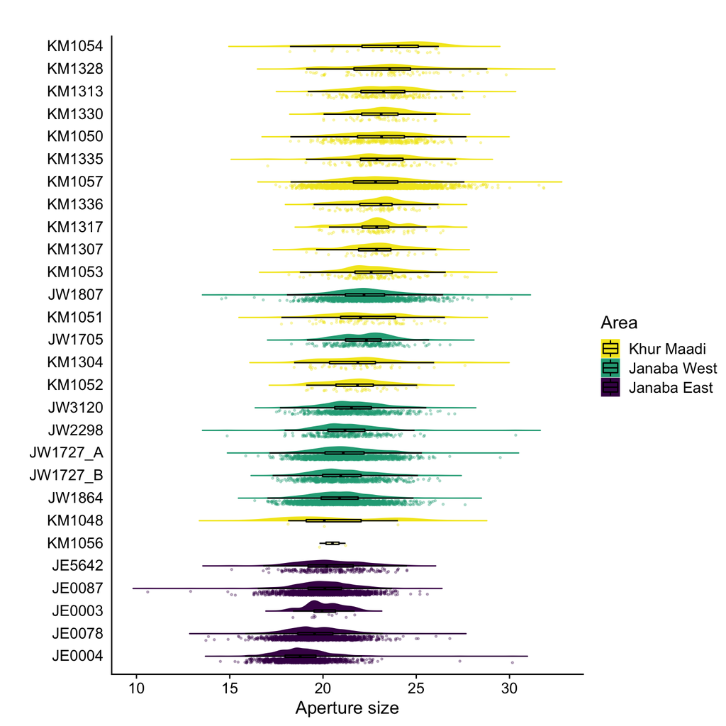

```r
library(ggplot2)
library(cowplot)
library(viridis)
source('R_rainclouds.R')

 Fig6b <- Aps %>%
      ggplot(aes(
    x =   reorder(Site, Aperture, FUN = mean,order=TRUE),
    y = Aperture,
    fill = Area,
    colour = Area, order=Aperture
  )) +
    geom_flat_violin(
      position = position_nudge(x = +0.2, y = 0),
      adjust = 0.75,
      trim = FALSE,
      alpha = .99
    ) +
    geom_point(position = position_jitter(width = 0.1),
               size = 0.5,alpha=0.3
    ) +
    geom_boxplot(
      position = position_nudge(x = +0.2, y = 0),
      aes(x = Site, y = Aperture,colour=Area),
      outlier.shape = NA,
      alpha = 0.3,
      width = .1,
      colour = "BLACK"
    ) +
    ylab('Aperture size') + xlab("") + coord_flip() +guides(fill = guide_legend(reverse = TRUE),color = guide_legend(reverse = TRUE))+
    scale_color_manual(values=c(viridis_pal()(3)[1],viridis_pal()(6)[4],viridis_pal()(60)[59]))+
    scale_fill_manual(values=c(viridis_pal()(3)[1],viridis_pal()(6)[4],viridis_pal()(60)[59]))+    theme_cowplot()+ ggtitle("")+
    theme(axis.text.y.left = element_text(vjust=-0))+
    theme(axis.ticks.y=element_blank())+
    theme(legend.position="right")

  Fig6b
```

Finally, we want to integrate both raincloud plots (Areas and Sites) into one figure. For this we use the `patchwork` package.

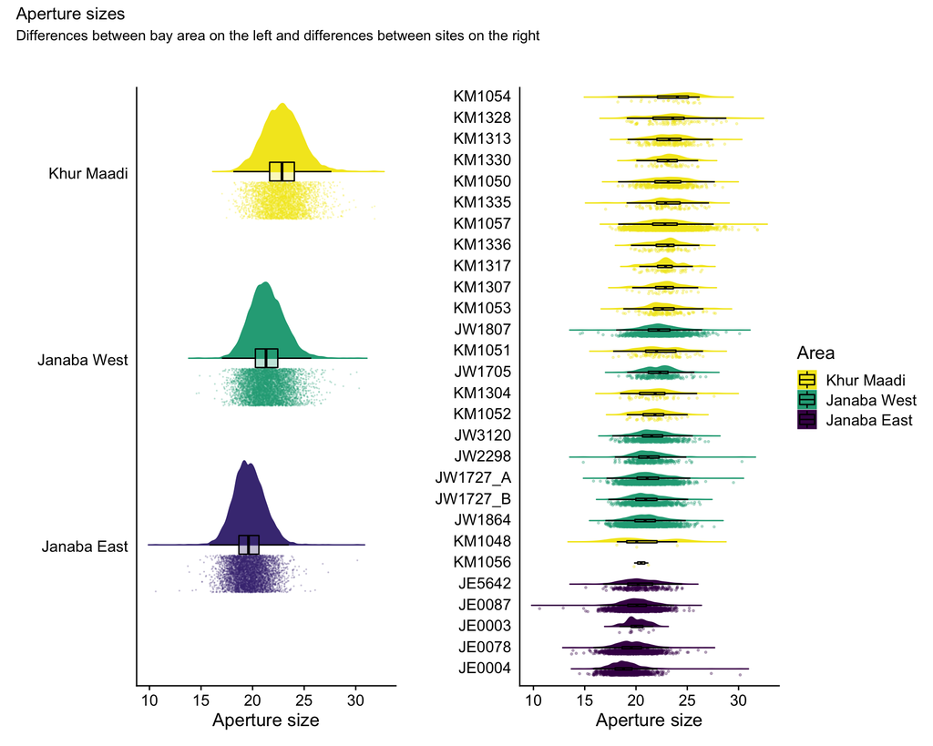

```r
library(patchwork)
Fig6 <- Fig6a+Fig6b

Fig6 + plot_annotation(
  title = 'Aperture sizes',
  subtitle = 'Differences between bay area on the left and differences between sites on the right')
```

```r
ggsave(here("Figures and supplementary material/Figure_6.png"),plot=Fig6, height = 200, width = 300, units = "mm")
```

# Time related changes in aperture sizes (Fig. 7)

For this step we will add the occupation times for each site. This step is done in the `SortApsByDate.R` script and essentially takes the minimum and maximum occupation period for each site and interpolates fictional dates for all bulk samples between the top and the bottom of the sample column. While this is not an ideal approach for analysing parallel changes between sites, they give us an idea of changes through time within individual sites and a rough grouping of data overall.

```r
library(xts)
source('SortApsByDate.R')

ApsByDate <- ApsByDate %>%
            select(Area,everything())

ApsByDate[1,1:5]
```

```
##              Area   Site Sample Aperture  Year
## 10304 Janaba East JE0004    676    18.45 -4830
```

To better illustrate trends within the dataset, we have averaged the aperture values for each bulk sample. That said, we did take into account the variability within each sample by scaling the size of each data point in the plot depending on each sample’s variability (see further below in Fig. 7a).

```r
source("summarySE.R")
MeanAps <-
  summarySE(
    na.omit(ApsByDate[, 1:5]),
    measurevar = c("Aperture"),
    groupvars = c("Sample")
  )

MeanYears <-
  summarySE(
    na.omit(ApsByDate[, 1:5]),
    measurevar = c("Year"),
    groupvars = c("Sample")
  )

MeanApsByDate <-
  data.frame(MeanAps[, c(1, 2, 3, 5)], MeanYears = MeanYears[, 3]) %>%
  merge( ApsByDate, by = "Sample") %>%
  select(-N,-Sample,-Order,-AreaOrder) %>%
  distinct()

head(MeanApsByDate)
```

```
##   Aperture_mean      sd MeanYears       Area   Site Aperture  Year
## 1      22.24089 1.72047   -5033.2 Khur Maadi KM1057    21.96 -5033
## 2      22.24089 1.72047   -5033.2 Khur Maadi KM1057    21.91 -5033
## 3      22.24089 1.72047   -5033.2 Khur Maadi KM1057    21.89 -5033
## 4      22.24089 1.72047   -5033.2 Khur Maadi KM1057    21.88 -5034
## 5      22.24089 1.72047   -5033.2 Khur Maadi KM1057    21.81 -5034
## 6      22.24089 1.72047   -5033.2 Khur Maadi KM1057    21.64 -5034
```

## Figure 7a changes in time including all data

To show the changes in aperture size distribution through time, we plotted each bulk sample’s mean aperture size as a point, that was itself larger or smaller depending on the variability of sizes within the specific bulk sample. We also overlayed this plot with the smoothed line using locally estimated scatterplot smoothing (LOESS).

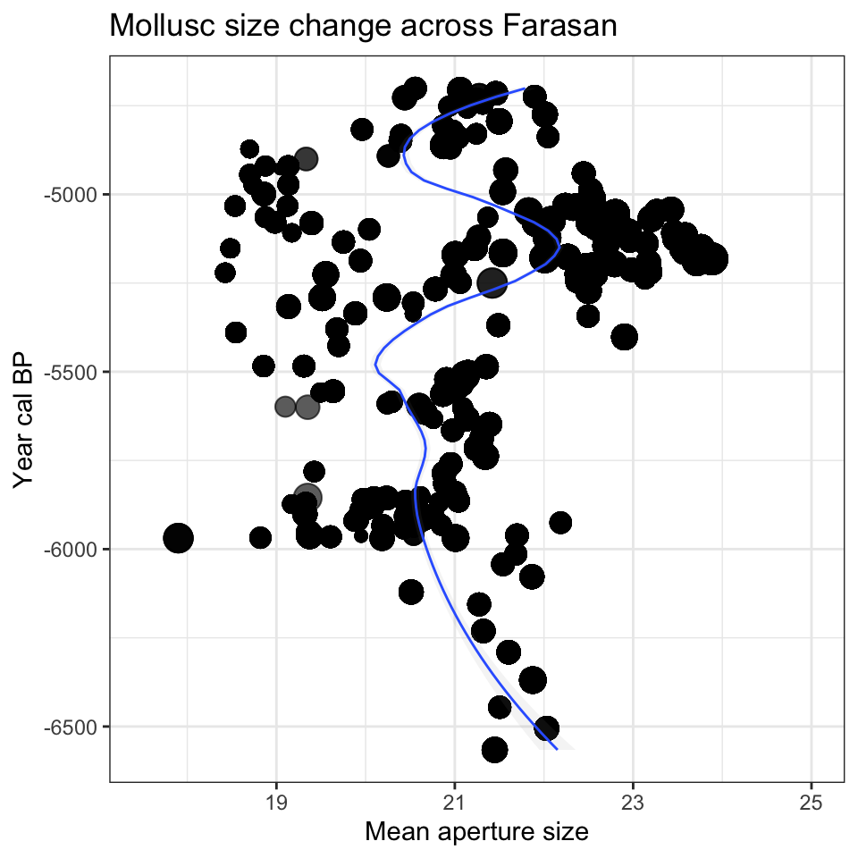

```r
Fig7a <- MeanApsByDate %>%
  ggplot(
    aes(x = MeanYears , y = Aperture_mean, size = sd)
  ) + scale_color_manual(values = 'steel') +
  geom_point(show.legend = TRUE, alpha = 0.4) + geom_smooth(
    method = "loess",
    span = 0.5,
    size = 0.5,
    alpha = 0.1
  ) +
  ylim(17.5, 25) + theme_bw() + guides(size = FALSE) + coord_flip() + theme(legend.position = c(0.8, 0.3)) +
  ylab('Mean aperture size') + xlab('Year cal BP') +
  scale_size(range = c(1.5, 6)) +  ggtitle("Mollusc size change across Farasan")

Fig7a
```

## Figure 7b changes in time between bay areas

We are then looking at the aperture size distribution across time for each bay areas individually.

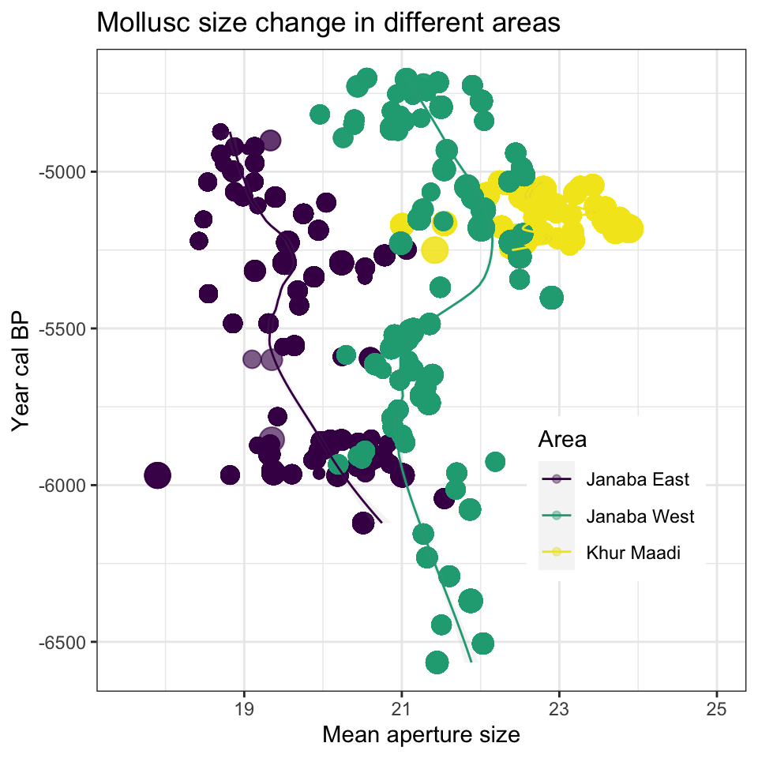

```r
library(viridis)
Fig7b <- MeanApsByDate %>%
  ggplot(aes(
    x = MeanYears ,
    y = Aperture_mean,
    size = sd,
    color = Area
  )) + scale_color_manual(values = c(viridis_pal()(3)[1], viridis_pal()(6)[4], viridis_pal()(60)[59])) +
  geom_point(show.legend = TRUE, alpha = 0.4) + geom_smooth(
    method = "loess",
    span = 0.5,
    size = 0.5,
    alpha = 0.1
  ) +
  ylim(17.5, 25) + theme_bw() + guides(size = FALSE) + coord_flip() + theme(legend.position = c(0.8, 0.3)) +
  ylab('Mean aperture size') + xlab('Year cal BP') +
  scale_size(range = c(1.5, 6)) +  ggtitle("Mollusc size change in different areas")

Fig7b
```

## Statistical test on trends between earlier and later periods

### Categorise aperture values by earlier and later periods within

To compare changes in time, which seem to be evident in Fig. 7b, we defined **Early** (6500–6000 calBP) and **Late** (5000–4800 cal BP) periods, into which the data from `ApsByDate` were grouped. Lastly these groups are combined into one dataframe (`Ttest.df`), which will be used to extract data for a two sample t-test in each bay area.

```r
EarlyAps <- ApsByDate %>%
            filter(Year%in% -6500:-6000) %>%
            mutate(Period=c("Early"))

LateAps <- ApsByDate %>%
            filter(Year%in% -5001:-4800) %>%
            mutate(Period=c("Late"))

Ttest.df <- rbind(EarlyAps,LateAps)

rm(EarlyAps,LateAps)

Ttest.df[c(1,1800),c(1,2,3,4,5,8)]
```

```
##             Area   Site Sample Aperture  Year Period
## 1    Janaba East JE5642   2552    18.30 -6000  Early
## 1800 Janaba West JW1807   2791    22.85 -4994   Late
```

### Test for changes

To test changes in time for Janaba West:

```r
Ttest.df %>%
  filter(Area=='Janaba West') %>%
  t.test(Aperture~Period, data=., var.equal=TRUE)
```

```
##
##  Two Sample t-test
##
## data:  Aperture by Period
## t = 3.9876, df = 1230, p-value = 7.069e-05
## alternative hypothesis: true difference in means is not equal to 0
## 95 percent confidence interval:
##  0.1985012 0.5830037
## sample estimates:
## mean in group Early  mean in group Late
##            21.64032            21.24957
```

To test changes in time for Janaba East:

```r
Ttest.df %>%
  filter(Area=='Janaba East') %>%
  t.test(Aperture~Period, data=., var.equal=TRUE)
```

```
##
##  Two Sample t-test
##
## data:  Aperture by Period
## t = 13.095, df = 584, p-value < 2.2e-16
## alternative hypothesis: true difference in means is not equal to 0
## 95 percent confidence interval:
##  1.676517 2.268130
## sample estimates:
## mean in group Early  mean in group Late
##            20.86722            18.89489
```

## Temporal changes within individual sites

To see whether these changes persist on a site-level, we group the data by site.

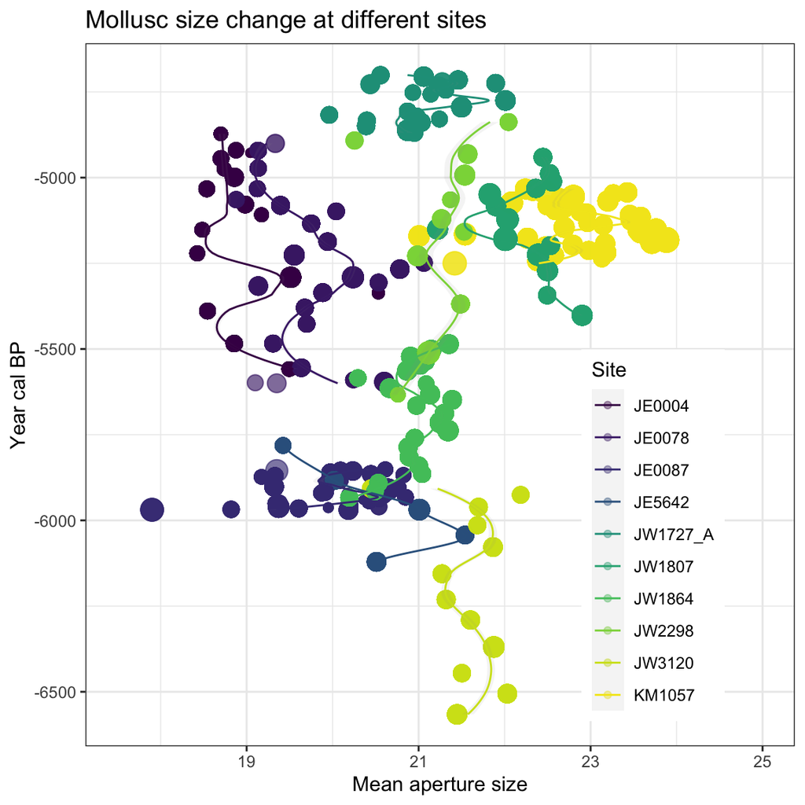

```r
Fig7c <- MeanApsByDate %>%
  ggplot(aes(
    x = MeanYears,
    y = Aperture_mean,
    size = sd,
    color = Site
  )) + scale_color_manual(
    values = rev(c(
      viridis_pal()(60)[59],
      #The colours are a bit tricky so we had to specify them individually for best results
      viridis_pal()(30)[28],
      viridis_pal()(30)[25],
      viridis_pal()(30)[22],
      viridis_pal()(30)[19],
      viridis_pal()(30)[17],
      viridis_pal()(30)[10],
      viridis_pal()(30)[6],
      viridis_pal()(30)[4],
      viridis_pal()(30)[1]
    ))
  ) +
  geom_point(show.legend = TRUE, alpha = 0.4) +
  geom_smooth(
    method = "loess",
    span = 0.5,
    size = 0.5,
    alpha = 0.1
  ) +
  ylim(17.5, 25) +
  theme_bw() +
  guides(size = FALSE) +
  coord_flip() +
  theme(legend.position = c(0.8, 0.3)) +
  ylab('Mean aperture size') + xlab('Year cal BP') +
  scale_size(range = c(1.5, 6)) +  ggtitle("Mollusc size change at different sites")

Fig7c
```

And we see that rather than a long-term decrease in size, we simply have changes in occupation of sites where shells are generally smaller.

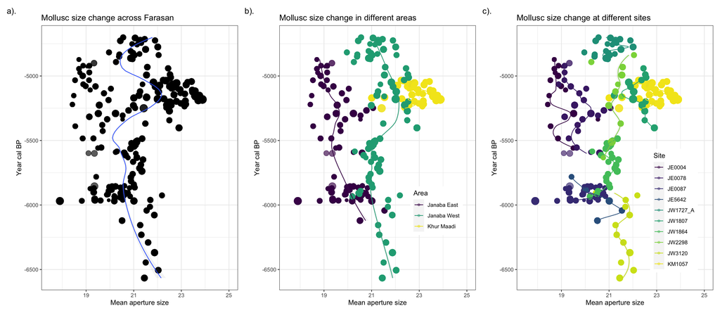

```r
Fig7 <- Fig7a+Fig7b+Fig7c

Fig7+plot_annotation(tag_levels = 'a', tag_suffix = ").")
```

```r
ggsave(here("/Figures and supplementary material/Figure_7.png"), height = 180, width = 180*2.3, units = "mm")
```